# Analyse performance

```r
library(tidyverse)
library(pROC)
library(ggthemes)
library(cowplot)
theme_set(theme_light())
```

```r
rm(list=ls())
set.seed(42)
```

```r
get_summary = function(infile) {

  df_all = read_csv(infile)

  df = df_all %>%
  mutate(true_y = ifelse(OUTCOME_ast_result == 'R', 1, 0)) %>%
  rename(abx = INFO_antibiotic)
  return(df)
}
```

```r
df1 = get_summary('data/predictions_co-amoxiclav.csv')
df2 = get_summary('data/predictions_amoxicillin.csv')
df3 = get_summary('data/predictions_piperacillin-tazobactam.csv')
df4 = get_summary('data/predictions_ceftriaxone.csv')
df5 = get_summary('data/predictions_ciprofloxacin.csv')
df6 = get_summary('data/predictions_co-trimoxazole.csv')
df7 = get_summary('data/predictions_gentamicin.csv')
```

```r
# merge df
df = bind_rows(df1, df2, df3, df4, df5, df6, df7)
```

Read in predictions from extended training period (train+test1)

```r
df1 = get_summary('data/predictions_extended_co-amoxiclav.csv')
df2 = get_summary('data/predictions_extended_amoxicillin.csv')
df3 = get_summary('data/predictions_extended_piperacillin-tazobactam.csv')
df4 = get_summary('data/predictions_extended_ceftriaxone.csv')
df5 = get_summary('data/predictions_extended_ciprofloxacin.csv')
df6 = get_summary('data/predictions_extended_co-trimoxazole.csv')
df7 = get_summary('data/predictions_extended_gentamicin.csv')
# merge df
df_extended = bind_rows(df1, df2, df3, df4, df5, df6, df7) %>%
  filter(dataset=="test2") %>%
  mutate(dataset="test2_extended")
```

Read in predictions from incrementally updated training (train… then test1)

```r
df1 = get_summary('data/predictions_updated_co-amoxiclav.csv')
df2 = get_summary('data/predictions_updated_amoxicillin.csv')
df3 = get_summary('data/predictions_updated_piperacillin-tazobactam.csv')
df4 = get_summary('data/predictions_updated_ceftriaxone.csv')
df5 = get_summary('data/predictions_updated_ciprofloxacin.csv')
df6 = get_summary('data/predictions_updated_co-trimoxazole.csv')
df7 = get_summary('data/predictions_updated_gentamicin.csv')
# merge df
df_updated = bind_rows(df1, df2, df3, df4, df5, df6, df7) %>%
  filter(dataset=="test2") %>%
  mutate(dataset="test2_updated")
```

Collect all data together

```r
df = bind_rows(df, df_extended, df_updated)
```

Import species data

```r
df1 = get_summary('data/predictions_species_co-amoxiclav.csv')
df2 = get_summary('data/predictions_species_amoxicillin.csv')
df3 = get_summary('data/predictions_species_piperacillin-tazobactam.csv')
df4 = get_summary('data/predictions_species_ceftriaxone.csv')
df5 = get_summary('data/predictions_species_ciprofloxacin.csv')
df6 = get_summary('data/predictions_species_co-trimoxazole.csv')
df7 = get_summary('data/predictions_species_gentamicin.csv')
df_species = bind_rows(df1, df2, df3, df4, df5, df6, df7) %>%
  mutate(dataset = paste0(dataset, "_species"))
```

```r
df = bind_rows(df, df_species)
```

```r
df %>% group_by(abx, dataset) %>%
  summarise(n=n(), n_resistant=sum(true_y), percent_resistant=round(100*n_resistant/n))
```

| abx | dataset | n | n_resistant | percent_resistant |
| --- | --- | --- | --- | --- |
| amoxicillin | test1 | 693 | 455 | 66 |
| amoxicillin | test1_species | 693 | 455 | 66 |
| amoxicillin | test2 | 711 | 459 | 65 |
| amoxicillin | test2_extended | 711 | 459 | 65 |
| amoxicillin | test2_species | 711 | 459 | 65 |
| amoxicillin | test2_updated | 711 | 459 | 65 |
| amoxicillin | train | 3260 | 2193 | 67 |
| amoxicillin | train_species | 3260 | 2193 | 67 |
| ceftriaxone | test1 | 701 | 78 | 11 |
| ceftriaxone | test1_species | 701 | 78 | 11 |

[output cut: 46 more lines]

```r
df %>%
  filter(dataset %in% c('train', 'test1', 'test2')) %>%
  group_by(abx) %>%
  summarise(n=n(), n_resistant=sum(true_y), percent_resistant=round(100*n_resistant/n))
```

| abx | n | n_resistant | percent_resistant |
| --- | --- | --- | --- |
| amoxicillin | 4664 | 3107 | 67 |
| ceftriaxone | 4677 | 526 | 11 |
| ciprofloxacin | 4701 | 584 | 12 |
| co-amoxiclav | 4666 | 1905 | 41 |
| co-trimoxazole | 4593 | 1011 | 22 |
| gentamicin | 4685 | 461 | 10 |
| piperacillin-tazobactam | 4691 | 341 | 7 |

```r
df %>%
  filter(dataset %in% c('train', 'test1', 'test2')) %>%
  select(pt, index_dt, INFO_accessionnumber, DEMOGRAPHICS_age, DEMOGRAPHICS_sex_M, COMORBIDITY_charlson_comorbidity_score,
              PREV_HOSP_STAY_days_since_admission_at_index_dt) %>%
  unique() %>%
  summarise(n_bc = n(), n_pt = n_distinct(pt),
            min(index_dt),
            max(index_dt),
            age_q50 = round(median(DEMOGRAPHICS_age)),
            age_q25 = round(quantile(DEMOGRAPHICS_age, c(0.25))),
            age_q75 = round(quantile(DEMOGRAPHICS_age, c(0.75))),
            n_male = sum(DEMOGRAPHICS_sex_M==1),
            pct_male = round(100*sum(DEMOGRAPHICS_sex_M==1)/n()),
            charlson_q50 = median(COMORBIDITY_charlson_comorbidity_score),
            charlson_q25 = quantile(COMORBIDITY_charlson_comorbidity_score, c(0.25)),
            charlson_q75 = quantile(COMORBIDITY_charlson_comorbidity_score, c(0.75)),
            ca = sum(PREV_HOSP_STAY_days_since_admission_at_index_dt<2),
            ca_pct = round(100*sum(PREV_HOSP_STAY_days_since_admission_at_index_dt<2)/n())
  )
```

| n_bc | n_pt | min(index_dt) | max(index_dt) | age_q50 | age_q25 | age_q75 | n_male | pct_male | charlson_q50 | charlson_q25 | charlson_q75 | ca | ca_pct |
| --- | --- | --- | --- | --- | --- | --- | --- | --- | --- | --- | --- | --- | --- |
| 4709 | 4243 | 2017-01-01 16:01:00 | 2023-12-30 19:16:00 | 74 | 60 | 84 | 2611 | 55 | 1 | 0 | 3 | 3631 | 77 |

```r
NA
```

```r
df %>% select(pt, index_dt, INFO_accessionnumber, dataset) %>%
  unique() %>%
  group_by(dataset) %>%
  summarise(n_distinct(pt, index_dt, INFO_accessionnumber), n_distinct(pt))
```

| dataset | n_distinct(pt, index_dt, INFO_accessionnumber) | n_distinct(pt) |
| --- | --- | --- |
| test1 | 706 | 674 |
| test1_species | 706 | 674 |
| test2 | 720 | 684 |
| test2_extended | 720 | 684 |
| test2_species | 720 | 684 |
| test2_updated | 720 | 684 |
| train | 3283 | 2982 |
| train_species | 3283 | 2982 |

Species isolated

```r
df %>%
  filter(dataset %in% c('train', 'test1', 'test2')) %>%
  select(pt, index_dt, INFO_bugname) %>%
  unique() %>%
  mutate(INFO_bugname = str_replace(INFO_bugname, '\\(ESBL\\)', '')) %>%
  group_by(bugname=INFO_bugname) %>%
  summarise(n=n()) %>%
  mutate(pct = round(100*n/sum(n),0)) %>%
  arrange(desc(n))
```

| bugname | n | pct |
| --- | --- | --- |
| ESCHERICHIA COLI | 3094 | 66 |
| KLEBSIELLA PNEUMONIAE | 545 | 12 |
| PROTEUS MIRABILIS | 203 | 4 |
| ENTEROBACTER CLOACAE | 177 | 4 |
| KLEBSIELLA OXYTOCA | 153 | 3 |
| SERRATIA MARCESCENS | 110 | 2 |
| CITROBACTER SPECIES | 81 | 2 |
| KLEBSIELLA VARIICOLA | 77 | 2 |
| KLEBSIELLA AEROGENES | 65 | 1 |
| MORGANELLA MORGANII | 45 | 1 |

[output cut: 36 more lines]

```r
df %>%
  filter(dataset %in% c('train', 'test1', 'test2')) %>%
  select(abx, OUTCOME_ast_result) %>%
  mutate(OUTCOME_ast_result = ifelse(str_detect(OUTCOME_ast_result, 'I'), 'S', OUTCOME_ast_result)) %>% #recode intermediate results as sensitive
  group_by(abx, OUTCOME_ast_result) %>%
  summarise(n=n()) %>%
  pivot_wider(names_from = OUTCOME_ast_result, values_from = n) %>%
  rename(ast_s = S, ast_r = R) %>%
  mutate(n=ast_s+ast_r) %>%
  mutate(pct_s = round(100*ast_s/n,0), pct_r = round(100*ast_r/n,0))
```

| abx | ast_r | ast_s | n | pct_s | pct_r |
| --- | --- | --- | --- | --- | --- |
| amoxicillin | 3107 | 1557 | 4664 | 33 | 67 |
| ceftriaxone | 526 | 4151 | 4677 | 89 | 11 |
| ciprofloxacin | 584 | 4117 | 4701 | 88 | 12 |
| co-amoxiclav | 1905 | 2761 | 4666 | 59 | 41 |
| co-trimoxazole | 1011 | 3582 | 4593 | 78 | 22 |
| gentamicin | 461 | 4224 | 4685 | 90 | 10 |
| piperacillin-tazobactam | 341 | 4350 | 4691 | 93 | 7 |

Baseline antibiotics

```r
df %>%
  filter(dataset %in% c('train', 'test1', 'test2')) %>%
  select(pt, index_dt, INFO_BASELINE_ABX_baseline_abx) %>%
  unique() %>%
  group_by(INFO_base_abx=INFO_BASELINE_ABX_baseline_abx) %>%
  count() %>%
  arrange(desc(n)) %>%
  ungroup() %>%
  mutate(pct = round(100*n/sum(n),0))
```

| INFO_base_abx | n | pct |
| --- | --- | --- |
| co-amoxiclav | 1194 | 25 |
| NA | 883 | 19 |
| co-amoxiclav,gentamicin | 761 | 16 |
| ceftriaxone | 236 | 5 |
| piperacillin-tazobactam | 109 | 2 |
| ceftriaxone,gentamicin | 98 | 2 |
| co-amoxiclav,metronidazole | 84 | 2 |
| co-amoxiclav,gentamicin,metronidazole | 72 | 2 |
| aciclovir,piperacillin-tazobactam,posaconazole | 50 | 1 |
| clarithromycin,co-amoxiclav | 38 | 1 |

[output cut: 379 more lines]

baseline carbapenem

```r
df %>%
  filter(dataset %in% c('train', 'test1', 'test2')) %>%
  select(pt, index_dt, INFO_BASELINE_ABX_baseline_abx) %>%
  unique() %>%
  filter(str_detect(INFO_BASELINE_ABX_baseline_abx, 'penem')) %>%
  count()
```

| n |
| --- |
| 90 |

```r
df %>%
  group_by(dataset) %>%
  summarise(n_distinct(pt), n_distinct(pt, index_dt, INFO_accessionnumber))
```

| dataset | n_distinct(pt) | n_distinct(pt, index_dt, INFO_accessionnumber) |
| --- | --- | --- |
| test1 | 674 | 706 |
| test1_species | 674 | 706 |
| test2 | 684 | 720 |
| test2_extended | 684 | 720 |
| test2_species | 684 | 720 |
| test2_updated | 684 | 720 |
| train | 2982 | 3283 |
| train_species | 2982 | 3283 |

```r
a_resistance = df %>% select(dataset, abx, OUTCOME_ast_result) %>%
  mutate(abx = factor(str_to_sentence(abx),
                      levels = c("Amoxicillin", "Co-amoxiclav", "Ceftriaxone", "Piperacillin-tazobactam", "Ciprofloxacin", "Co-trimoxazole", "Gentamicin"))) %>%
  mutate(OUTCOME_ast_result = ifelse(str_detect(OUTCOME_ast_result, 'I'), 'S', OUTCOME_ast_result)) %>% #recode intermediate results as sensitive
  group_by(dataset, abx, OUTCOME_ast_result) %>%
  summarise(n=n()) %>%
  pivot_wider(names_from = OUTCOME_ast_result, values_from = n) %>%
  rename(ast_s = S, ast_r = R) %>%
  mutate(n=ast_s+ast_r) %>%
  mutate(pct_s = round(100*ast_s/n,0), pct_r = round(100*ast_r/n,0))
a_resistance %>% write_csv('data/datasets_antibiotic_resistance.csv')
a_resistance
```

| dataset | abx | ast_r | ast_s | n | pct_s | pct_r |
| --- | --- | --- | --- | --- | --- | --- |
| test1 | Amoxicillin | 455 | 238 | 693 | 34 | 66 |
| test1 | Co-amoxiclav | 283 | 416 | 699 | 60 | 40 |
| test1 | Ceftriaxone | 78 | 623 | 701 | 89 | 11 |
| test1 | Piperacillin-tazobactam | 64 | 640 | 704 | 91 | 9 |
| test1 | Ciprofloxacin | 86 | 620 | 706 | 88 | 12 |
| test1 | Co-trimoxazole | 123 | 565 | 688 | 82 | 18 |
| test1 | Gentamicin | 75 | 629 | 704 | 89 | 11 |
| test1_species | Amoxicillin | 455 | 238 | 693 | 34 | 66 |
| test1_species | Co-amoxiclav | 283 | 416 | 699 | 60 | 40 |
| test1_species | Ceftriaxone | 78 | 623 | 701 | 89 | 11 |

[output cut: 46 more lines]

get performance characteristics

```r
get_perf = function(df_function) {
  ss = df_function %>%
  group_by(dataset, abx) %>%
  summarise(tp = sum(true_y==1 & calib_pred_y==1),
            tn = sum(true_y==0 & calib_pred_y==0),
            fp = sum(true_y==0 & calib_pred_y==1),
            fn = sum(true_y==1 & calib_pred_y==0),
            .groups = "drop_last") %>%
  mutate(sens = round(100*tp/(tp+fn),1), spec = round(100*tn/(tn+fp),1),
         ppv = round(100*tp/(tp+fp),1), npv = round(100*tn/(tn+fn),1)) %>%
  select(-tp, -tn, -fp, -fn)

roc = df_function %>%
  group_by(dataset, abx) %>%
  do({
    roc_obj = roc(.$true_y, .$calib_prob_y, levels=c(0, 1), direction="<")
    data.frame(
      abx = .$abx[1],
      auc = round(roc_obj$auc, 3)
    )
  })

return(inner_join(roc, ss, by = c('dataset', 'abx')))
}

get_summary = function(point_est, out_iter) {
  out = out_iter %>%
  group_by(dataset, abx) %>%
  summarise(auc_q025 = quantile(auc, 0.025, na.rm=T), auc_q975 = quantile(auc, 0.975, na.rm=T),
            sens_q025 = quantile(sens, 0.025, na.rm=T), sens_q975 = quantile(sens, 0.975, na.rm=T),
            spec_q025 = quantile(spec, 0.025, na.rm=T), spec_q975 = quantile(spec, 0.975, na.rm=T),
            ppv_q025 = quantile(ppv, 0.025, na.rm=T), ppv_q975 = quantile(ppv, 0.975, na.rm=T),
            npv_q025 = quantile(npv, 0.025, na.rm=T), npv_q975 = quantile(npv, 0.975, na.rm=T),
            .groups = "drop_last"
            ) %>%
  mutate(auc_ci = paste0("(",sprintf("%.3f", auc_q025), ' - ', sprintf("%.3f", auc_q975),")"),
         sens_ci = paste0("(",sprintf("%.1f", sens_q025), ' - ', sprintf("%.1f", sens_q975),")"),
         spec_ci = paste0("(",sprintf("%.1f", spec_q025), ' - ', sprintf("%.1f", spec_q975),")"),
         ppv_ci = paste0("(",sprintf("%.1f", ppv_q025), ' - ', sprintf("%.1f", ppv_q975),")"),
         npv_ci = paste0("(",sprintf("%.1f", npv_q025), ' - ', sprintf("%.1f", npv_q975),")")) %>%
  select(dataset, abx, auc_ci, sens_ci, spec_ci, ppv_ci, npv_ci) %>%
  inner_join(point_est, by = c('dataset', 'abx')) %>%
  mutate(auc = paste0(sprintf("%.3f", auc), ' ', auc_ci)) %>%
  mutate(sens = paste0(sprintf("%.1f", sens), ' ', sens_ci)) %>%
  mutate(spec = paste0(sprintf("%.1f", spec), ' ', spec_ci)) %>%
  mutate(ppv = paste0(sprintf("%.1f", ppv), ' ', ppv_ci)) %>%
  mutate(npv = paste0(sprintf("%.1f", npv), ' ', npv_ci)) %>%
  select(dataset, abx, auc, sens, spec, ppv, npv)

  return(out)
}
```

```r
df_perf = df %>%
  select(dataset, abx, true_y, prob_y, calib_prob_y, calib_pred_y) %>%
    mutate(abx = factor(str_to_sentence(abx),
                      levels = c("Amoxicillin", "Co-amoxiclav", "Ceftriaxone", "Piperacillin-tazobactam", "Ciprofloxacin", "Co-trimoxazole", "Gentamicin")))

point_est = get_perf(df_perf)

iter = 1000
out_iter = tibble()
for (i in 1:iter) {
  if(i%%100==0) {
    print(i)
  }
  out_iter = bind_rows(out_iter, get_perf(df_perf %>% sample_n(n(), replace = TRUE)) %>% mutate(i_row = i))
}
```

```
[1] 100
[1] 200
[1] 300
[1] 400
[1] 500
[1] 600
[1] 700
[1] 800
[1] 900
[1] 1000
```

```r
a_performance = get_summary(point_est, out_iter)
a_performance %>% write_csv('data/datasets_performance.csv')
a_performance
```

| dataset | abx | auc | sens | spec | ppv | npv |
| --- | --- | --- | --- | --- | --- | --- |
| test1 | Amoxicillin | 0.680 (0.641 - 0.720) | 62.2 (57.8 - 66.6) | 66.4 (60.2 - 72.3) | 78.0 (73.9 - 81.9) | 47.9 (42.6 - 53.7) |
| test1 | Co-amoxiclav | 0.684 (0.642 - 0.722) | 60.4 (54.7 - 66.1) | 67.8 (63.7 - 71.9) | 56.1 (50.5 - 61.3) | 71.6 (67.8 - 75.8) |
| test1 | Ceftriaxone | 0.737 (0.674 - 0.797) | 48.7 (37.5 - 60.2) | 83.0 (80.1 - 85.9) | 26.4 (19.2 - 34.2) | 92.8 (90.6 - 94.9) |
| test1 | Piperacillin-tazobactam | 0.708 (0.643 - 0.779) | 51.6 (39.6 - 63.8) | 79.1 (75.8 - 82.1) | 19.8 (14.2 - 26.3) | 94.2 (92.2 - 96.0) |
| test1 | Ciprofloxacin | 0.726 (0.655 - 0.789) | 50.0 (39.2 - 60.6) | 88.2 (85.7 - 90.6) | 37.1 (28.0 - 45.4) | 92.7 (90.6 - 94.8) |
| test1 | Co-trimoxazole | 0.698 (0.641 - 0.754) | 40.7 (32.7 - 49.6) | 91.5 (89.2 - 93.7) | 51.0 (41.7 - 60.5) | 87.6 (84.8 - 90.3) |
| test1 | Gentamicin | 0.700 (0.625 - 0.775) | 45.3 (34.2 - 57.1) | 85.2 (82.6 - 88.0) | 26.8 (19.4 - 35.2) | 92.9 (90.6 - 94.8) |
| test1_species | Amoxicillin | 0.827 (0.797 - 0.857) | 65.1 (60.8 - 69.9) | 85.7 (81.3 - 90.0) | 89.7 (86.4 - 92.8) | 56.2 (51.3 - 61.5) |
| test1_species | Co-amoxiclav | 0.771 (0.734 - 0.805) | 67.1 (61.0 - 72.6) | 72.8 (68.3 - 77.1) | 62.7 (57.3 - 68.1) | 76.5 (72.4 - 80.7) |
| test1_species | Ceftriaxone | 0.799 (0.745 - 0.846) | 64.1 (53.1 - 73.9) | 77.5 (74.1 - 80.9) | 26.3 (19.8 - 32.4) | 94.5 (92.5 - 96.3) |

[output cut: 46 more lines]

Merge into combined output

```r
inner_join(a_resistance, a_performance, by = c('dataset', 'abx')) %>%
  select(dataset, abx, n, ast_r, pct_r, auc, sens, spec, ppv, npv) %>%
  write_csv('data/datasets_combined_resistance_performance.csv')
```

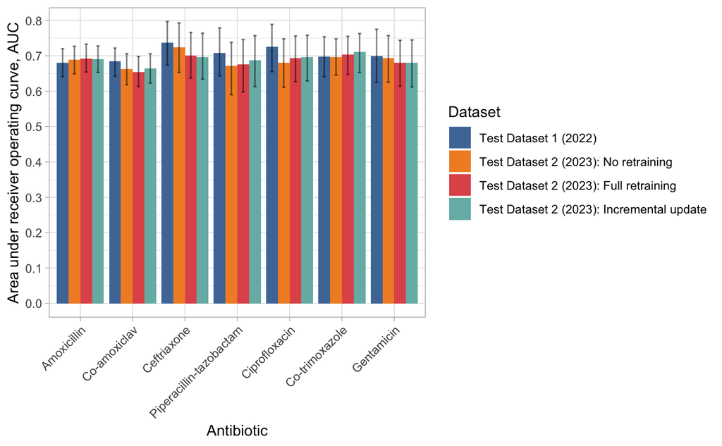

```r
point_est %>%
  filter(dataset %in% c('test1', 'test2', 'test2_extended', 'test2_updated')) %>%
  inner_join(
    out_iter %>%
    group_by(dataset, abx) %>%
    summarise(q025 = quantile(auc, 0.025, na.rm=T), q975 = quantile(auc, 0.975, na.rm=T))
  ) %>%
  mutate(dataset = factor(dataset, levels = c('train', 'test1', 'test2', 'test2_extended', 'test2_updated'),
                        labels = c('Training Dataset (2017-2021)',
                          'Test Dataset 1 (2022)', 'Test Dataset 2 (2023): No retraining', 'Test Dataset 2 (2023): Full retraining',
                                   'Test Dataset 2 (2023): Incremental update'))) %>%
  ggplot(aes(x=abx, y=auc, ymin=q025, ymax=q975, fill=dataset)) +
  geom_bar(stat='identity', position='dodge') +
  geom_errorbar(position=position_dodge(width=0.9), width=0.25, alpha=0.5) +
  theme(axis.text.x = element_text(angle = 45, hjust = 1)) +
  xlab('Antibiotic') +
  ylab('Area under receiver operating curve, AUC') +
  scale_fill_tableau(name="Dataset") +
  scale_y_continuous(breaks = seq(0, 1, 0.1))
ggsave('figures/test2_auc_comparison.pdf', width=8, height=5)
```

```r
df_tt = read_csv('data/training_time.csv')
```

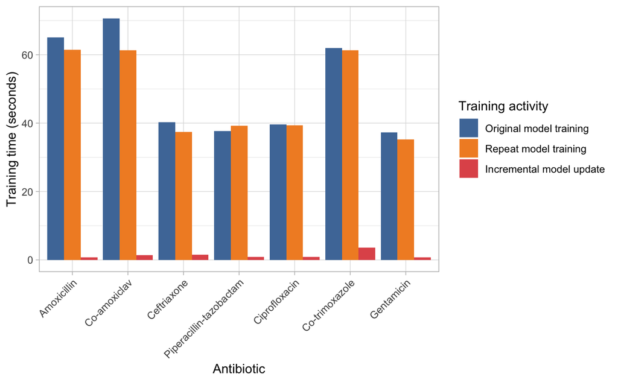

```r
df_tt %>%
  filter(species==0) %>%
    mutate(abx = factor(str_to_sentence(abx),
                      levels = c("Amoxicillin", "Co-amoxiclav", "Ceftriaxone", "Piperacillin-tazobactam", "Ciprofloxacin", "Co-trimoxazole", "Gentamicin"))) %>%
  mutate(activity = case_when(
    train_data == 'train' ~ 'Original model training',
    train_data == 'train_extended' ~ 'Repeat model training',
    train_data == 'update_model' ~ 'Incremental model update'
  )) %>%
    mutate(activity = factor(activity,
                      levels = c("Original model training", "Repeat model training", "Incremental model update"))) %>%
  ggplot(aes(x=abx, y=time_seconds, fill=activity)) +
  geom_bar(stat='identity', position='dodge') +
  theme(axis.text.x = element_text(angle = 45, hjust = 1)) +
  xlab('Antibiotic') +
  ylab('Training time (seconds)') +
  scale_fill_tableau(name="Training activity")
ggsave('figures/training_time.pdf', width=8, height=5)
```

Repeat setting sensitivity to 80%

```r
threshold = df_perf %>%
  filter(true_y==1) %>%
  filter(dataset=="test2") %>%
  group_by(abx) %>%
  arrange(abx, calib_prob_y) %>%
  mutate(row = row_number(), n=n(), pct=round(100*row/n(),1)) %>%
  filter(pct>=20) %>%
  slice(1) %>%
  select(abx, calib_threshold=calib_prob_y)

threshold
```

| abx | calib_threshold |
| --- | --- |
| Amoxicillin | 0.53950674 |
| Co-amoxiclav | 0.29355022 |
| Ceftriaxone | 0.05500509 |
| Piperacillin-tazobactam | 0.03848336 |
| Ciprofloxacin | 0.06054362 |
| Co-trimoxazole | 0.15905931 |
| Gentamicin | 0.05566429 |

calib

```r
df_perf2 = df_perf %>% inner_join(threshold) %>%
  mutate(calib_pred_y = ifelse(calib_prob_y>=calib_threshold, 1, 0))
point_est = get_perf(df_perf2)

iter = 1000
out_iter = tibble()
for (i in 1:iter) {
  if(i%%100==0) {
    print(i)
  }
  out_iter = bind_rows(out_iter, get_perf(df_perf2 %>% sample_n(n(), replace = TRUE)) %>% mutate(i_row = i))
}
```

```
[1] 100
[1] 200
[1] 300
[1] 400
[1] 500
[1] 600
[1] 700
[1] 800
[1] 900
[1] 1000
```

```r
a_s80 = get_summary(point_est, out_iter)
a_s80 %>% write_csv('data/datasets_performance_s80.csv')
a_s80
```

| dataset | abx | auc | sens | spec | ppv | npv |
| --- | --- | --- | --- | --- | --- | --- |
| test1 | Amoxicillin | 0.680 (0.639 - 0.721) | 80.9 (77.3 - 84.5) | 42.4 (36.2 - 48.4) | 72.9 (69.1 - 76.5) | 53.7 (47.1 - 60.9) |
| test1 | Co-amoxiclav | 0.684 (0.643 - 0.725) | 79.5 (74.7 - 83.9) | 39.2 (34.7 - 43.8) | 47.1 (42.6 - 51.4) | 73.8 (67.8 - 79.5) |
| test1 | Ceftriaxone | 0.737 (0.672 - 0.798) | 79.5 (69.9 - 88.7) | 45.7 (41.8 - 49.7) | 15.5 (11.9 - 19.3) | 94.7 (92.2 - 97.2) |
| test1 | Piperacillin-tazobactam | 0.708 (0.641 - 0.781) | 85.9 (77.6 - 94.0) | 37.7 (33.9 - 41.6) | 12.1 (9.1 - 15.1) | 96.4 (93.9 - 98.5) |
| test1 | Ciprofloxacin | 0.726 (0.657 - 0.790) | 76.7 (67.4 - 85.4) | 44.0 (40.1 - 48.1) | 16.0 (12.8 - 19.5) | 93.2 (90.2 - 95.9) |
| test1 | Co-trimoxazole | 0.698 (0.636 - 0.756) | 70.7 (61.8 - 78.9) | 52.6 (48.6 - 56.5) | 24.5 (20.1 - 28.9) | 89.2 (85.6 - 92.7) |
| test1 | Gentamicin | 0.700 (0.628 - 0.775) | 72.0 (62.0 - 82.5) | 51.2 (47.3 - 55.1) | 15.0 (11.5 - 18.7) | 93.9 (91.2 - 96.3) |
| test1_species | Amoxicillin | 0.827 (0.798 - 0.858) | 78.9 (75.2 - 82.6) | 68.1 (62.5 - 74.0) | 82.5 (79.0 - 86.1) | 62.8 (57.3 - 68.9) |
| test1_species | Co-amoxiclav | 0.771 (0.734 - 0.806) | 76.7 (71.7 - 81.6) | 56.0 (51.3 - 60.8) | 54.2 (49.3 - 59.1) | 77.9 (73.7 - 82.6) |
| test1_species | Ceftriaxone | 0.799 (0.749 - 0.849) | 83.3 (75.0 - 90.9) | 56.3 (52.5 - 60.4) | 19.3 (15.2 - 23.5) | 96.4 (94.6 - 98.2) |

[output cut: 46 more lines]

# Clinical comparison

## prepare dataset for clinical comparison

```r
dfa = df %>%
  filter(dataset %in% c('train', 'test1', 'test2'))
```

Check starting number of samples

```r
dfa %>%
  summarise(n_distinct(pt, index_dt, INFO_accessionnumber))
```

| n_distinct(pt, index_dt, INFO_accessionnumber) |
| --- |
| 4709 |

No baseline antibiotics

```r
dfa %>%
  filter(is.na(INFO_BASELINE_ABX_baseline_abx)) %>%
  summarise(n_distinct(pt, index_dt, INFO_accessionnumber))
```

| n_distinct(pt, index_dt, INFO_accessionnumber) |
| --- |
| 883 |

Not treated with a beta-lactam

```r
dfa %>%
  filter(!is.na(INFO_BASELINE_ABX_baseline_abx)) %>%
  filter(is.na(INFO_BASELINE_ABX_last_betalactam)) %>%
  summarise(n_distinct(pt, index_dt, INFO_accessionnumber))
```

| n_distinct(pt, index_dt, INFO_accessionnumber) |
| --- |
| 381 |

Neutropenic

```r
dfa %>%
  filter(!is.na(INFO_BASELINE_ABX_baseline_abx)) %>%
  filter(!is.na(INFO_BASELINE_ABX_last_betalactam)) %>%
  filter(!(INFO_LABS_neutrophils_most_recent_72h>1 | is.na(INFO_LABS_neutrophils_most_recent_72h))) %>%
  summarise(n_distinct(pt, index_dt, INFO_accessionnumber))
```

| n_distinct(pt, index_dt, INFO_accessionnumber) |
| --- |
| 210 |

Missing ast result for one of the beta-lactams

```r
dfa %>%
  filter(!is.na(INFO_BASELINE_ABX_baseline_abx)) %>%
  filter(!is.na(INFO_BASELINE_ABX_last_betalactam)) %>%
  filter((INFO_LABS_neutrophils_most_recent_72h>1 | is.na(INFO_LABS_neutrophils_most_recent_72h))) %>%
  mutate(OUTCOME_ast_result = ifelse(str_detect(OUTCOME_ast_result, 'I'), 'R', OUTCOME_ast_result)) %>% #recode intermediate results as resistant
  rename(baseline_abx=INFO_BASELINE_ABX_baseline_abx, ast_s=INFO_BASELINE_AST_baseline_abx_sensitive, ast_r=INFO_BASELINE_AST_baseline_abx_resistant, ast_i=INFO_BASELINE_AST_baseline_abx_intermediate) %>%
  # remove patients missing an AST result for one of the baseline antibiotics
  mutate(ast_all = paste(ast_s, ast_r, ast_i, sep = '|')) %>%
  filter(!(str_detect(ast_all, 'amoxicillin') &
             str_detect(ast_all, 'co-amoxiclav') &
             str_detect(ast_all, 'piperacillin-tazobactam') &
             str_detect(ast_all, 'ceftriaxone'))) %>%
  summarise(n_distinct(pt, index_dt, INFO_accessionnumber))
```

| n_distinct(pt, index_dt, INFO_accessionnumber) |
| --- |
| 37 |

Create comparison dataset

```r
df_abx = dfa %>%
  filter(!is.na(INFO_BASELINE_ABX_baseline_abx)) %>% #remove patients without any recorded baseline antibiotics
  filter(!is.na(INFO_BASELINE_ABX_last_betalactam)) %>% # restrict to those receiving a common beta-lactam
  filter(INFO_LABS_neutrophils_most_recent_72h>1 | is.na(INFO_LABS_neutrophils_most_recent_72h)) %>% #exclude neutropenic sepsis
  mutate(OUTCOME_ast_result = ifelse(str_detect(OUTCOME_ast_result, 'I'), 'R', OUTCOME_ast_result)) %>% #recode intermediate results as resistant
  rename(baseline_abx=INFO_BASELINE_ABX_baseline_abx, ast_s=INFO_BASELINE_AST_baseline_abx_sensitive, ast_r=INFO_BASELINE_AST_baseline_abx_resistant, ast_i=INFO_BASELINE_AST_baseline_abx_intermediate) %>%
  # remove patients missing an AST result for one of the baseline antibiotics
  mutate(ast_all = paste(ast_s, ast_r, ast_i, sep = '|')) %>%
  filter((str_detect(ast_all, 'amoxicillin') &
             str_detect(ast_all, 'co-amoxiclav') &
             str_detect(ast_all, 'piperacillin-tazobactam') &
             str_detect(ast_all, 'ceftriaxone'))) %>%
  mutate(target_abx_in_baseline_abx = ifelse(str_detect(baseline_abx, abx), 1, 0)) %>%
  mutate(ast_s_search = str_replace(str_replace_all(ast_s, ',', '|'), "\\+", "\\\\+")) %>% # convert to regexp string, covering comma to | and escaping + in piptaz
  mutate(active_abx = ifelse(is.na(ast_s) | str_detect(baseline_abx, ast_s_search), 1, 0))
```

```r
df_abx %>%
  summarise(n_pt=n_distinct(pt), n_bc=n_distinct(pt, index_dt, INFO_accessionnumber))
```

| n_pt | n_bc |
| --- | --- |
| 2931 | 3198 |

```r
df_abx %>%
  group_by(dataset=ifelse(dataset=="train", "train", "test")) %>%
  summarise(n_pt=n_distinct(pt), n_bc=n_distinct(pt, index_dt, INFO_accessionnumber))
```

| dataset | n_pt | n_bc |
| --- | --- | --- |
| test | 878 | 919 |
| train | 2102 | 2279 |

Resistance rate to mero

```r
df_abx %>% select(dataset, pt, index_dt, INFO_accessionnumber, ast_r) %>% unique() %>%
  filter(str_detect(ast_r, 'meropenem')) %>%
  group_by(dataset) %>%
  summarise(n_bc_r_mero=n_distinct(pt, index_dt, INFO_accessionnumber))
```

| dataset | n_bc_r_mero |
| --- | --- |
| test1 | 1 |
| test2 | 1 |
| train | 1 |

Collapse dataset to one row per blood culture

```r
pt_list = df_abx %>%
  filter(abx=="co-amoxiclav") %>%
  select(dataset, pt, index_dt, INFO_accessionnumber, baseline_abx, active_abx, ast_s, ast_i, ast_r, last_betalactam=INFO_BASELINE_ABX_last_betalactam) %>%
    mutate(baseline_abx_gp = case_when(
    str_detect(last_betalactam, 'meropenem|ertapenem') ~ 'carbapenem',
    str_detect(last_betalactam, 'piperacillin-tazobactam') ~ 'piperacillin-tazobactam',
    str_detect(last_betalactam, 'ceftriaxone') ~ 'ceftriaxone',
    str_detect(last_betalactam, 'co-amoxiclav') ~ 'co-amoxiclav',
    str_detect(last_betalactam, 'amoxicillin') ~ 'amoxicillin',
    TRUE ~ 'other'
  )) %>%
  filter(baseline_abx_gp != 'other') %>%
  mutate(ast_s_search = str_replace_all(ast_s, ',', '|')) %>%
  mutate(active_betalactam = ifelse(str_detect(last_betalactam, ast_s_search), 1, 0))
```

```r
pt_list = pt_list %>%
  mutate(rx = case_when(
    active_betalactam == 0 ~ 'under_treated',
    baseline_abx_gp == 'amoxicillin' & active_betalactam == 1 ~ 'optimal',
    baseline_abx_gp == 'co-amoxiclav' & active_betalactam == 1 & str_detect('amoxicillin', ast_s_search) ~ 'over_treated',
    baseline_abx_gp == 'co-amoxiclav' & active_betalactam == 1 & !str_detect('amoxicillin', ast_s_search) ~ 'optimal',
    baseline_abx_gp == 'ceftriaxone' & active_betalactam == 1 & str_detect('amoxicillin|co-amoxiclav', ast_s_search) ~ 'over_treated',
    baseline_abx_gp == 'ceftriaxone' & active_betalactam == 1 & !str_detect('amoxicillin|co-amoxiclav', ast_s_search) ~ 'optimal',
    baseline_abx_gp == 'piperacillin-tazobactam' & active_betalactam == 1 & str_detect('amoxicillin|co-amoxiclav|ceftriaxone', ast_s_search) ~ 'over_treated',
    baseline_abx_gp == 'piperacillin-tazobactam' & active_betalactam == 1 & !str_detect('amoxicillin|co-amoxiclav|ceftriaxone', ast_s_search) ~ 'optimal',
    baseline_abx_gp == 'carbapenem' & active_betalactam == 1 & str_detect('amoxicillin|co-amoxiclav|ceftriaxone|piperacillin-tazobactam', ast_s_search) ~ 'over_treated',
    baseline_abx_gp == 'carbapenem' & active_betalactam == 1 & !str_detect('amoxicillin|co-amoxiclav|ceftriaxone|piperacillin-tazobactam', ast_s_search) ~ 'optimal',
    TRUE ~ 'other'
  )) %>%
  mutate(baseline_abx_gp = factor(baseline_abx_gp, levels = c('amoxicillin', 'co-amoxiclav', 'ceftriaxone', 'piperacillin-tazobactam', 'carbapenem'))) %>%
  mutate(baseline_abx_gp_plot = factor(baseline_abx_gp,
                                  levels = c('amoxicillin', 'co-amoxiclav', 'ceftriaxone', 'piperacillin-tazobactam', 'carbapenem'),
                                  labels = c('amoxicillin', 'co-amoxiclav', 'ceftriaxone', 'piperacillin-\ntazobactam', 'carbapenem'))) %>%
  mutate(optimal_rx = case_when(
    str_detect('amoxicillin', ast_s_search) ~ 'amoxicillin',
    str_detect('co-amoxiclav', ast_s_search) ~ 'co-amoxiclav',
    str_detect('ceftriaxone', ast_s_search) ~ 'ceftriaxone',
    str_detect('piperacillin-tazobactam', ast_s_search) ~ 'piperacillin-tazobactam',
    TRUE ~ 'carbapenem'
  )) %>%
  mutate(optimal_rx = factor(optimal_rx, levels = c('amoxicillin', 'co-amoxiclav', 'ceftriaxone', 'piperacillin-tazobactam', 'carbapenem'))) %>%
  mutate(optimal_rx_plot = factor(optimal_rx, levels = c('amoxicillin', 'co-amoxiclav', 'ceftriaxone', 'piperacillin-tazobactam', 'carbapenem'),
                                  labels = c('amoxicillin', 'co-amoxiclav', 'ceftriaxone', 'piperacillin-\ntazobactam', 'carbapenem')))
```

AST summary

```r
dfa %>%
  inner_join(pt_list %>% select(pt, index_dt, INFO_accessionnumber, dataset)) %>%
  group_by(abx) %>%
  summarise(n=n(), n_resistant=sum(true_y), percent_resistant=round(100*n_resistant/n))
```

| abx | n | n_resistant | percent_resistant |
| --- | --- | --- | --- |
| amoxicillin | 3198 | 2064 | 65 |
| ceftriaxone | 3198 | 320 | 10 |
| ciprofloxacin | 3196 | 379 | 12 |
| co-amoxiclav | 3198 | 1225 | 38 |
| co-trimoxazole | 3170 | 674 | 21 |
| gentamicin | 3195 | 318 | 10 |
| piperacillin-tazobactam | 3198 | 190 | 6 |

Any active treatment?

```r
pt_list %>% count(active_abx) %>% mutate(pct = n/sum(n))
```

| active_abx | n | pct |
| --- | --- | --- |
| 0 | 686 | 0.2145091 |
| 1 | 2512 | 0.7854909 |

## Clinician prescribing plots

baseline beta-lactam given and whether over or under treated vs AST results

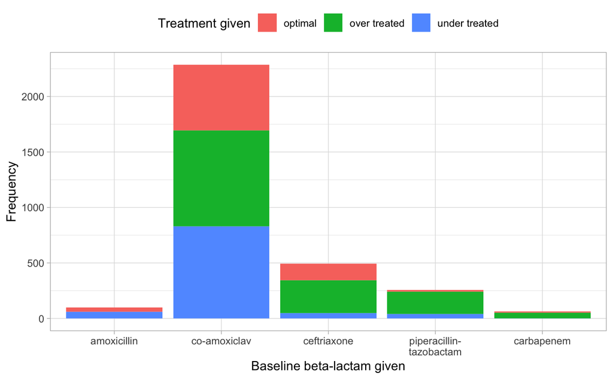

```r
p1 = pt_list %>%
  count(baseline_abx_gp_plot, rx) %>%
  ggplot(aes(x = baseline_abx_gp_plot, y = n, fill = str_replace(rx, '_', ' '))) +
  geom_bar(stat = 'identity', position = 'stack') +
  xlab("Baseline beta-lactam given") +
  ylab("Frequency") +
  scale_fill_discrete(name="Treatment given") +
  theme(legend.position = "top")
p1
```

```r
pt_list %>% count(rx) %>% mutate(pct = n/sum(n))
```

| rx | n | pct |
| --- | --- | --- |
| optimal | 806 | 0.2520325 |
| over_treated | 1418 | 0.4434021 |
| under_treated | 974 | 0.3045654 |

Optimal treatment based on AST results

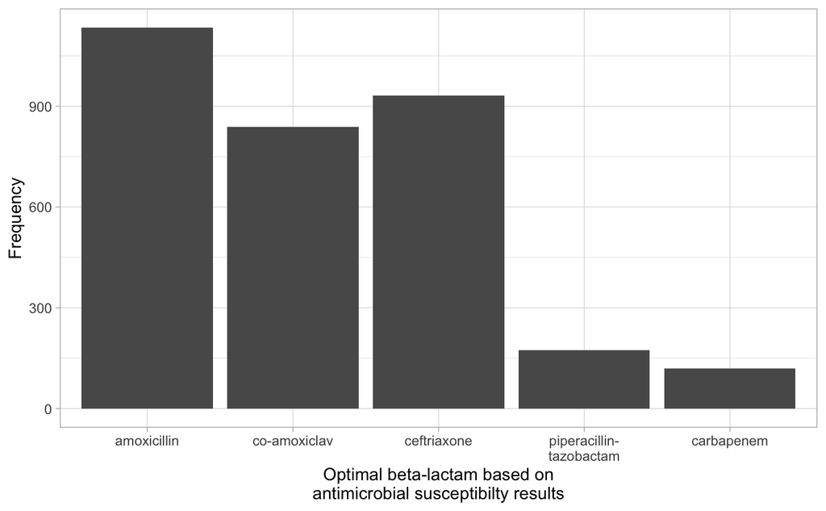

```r
p2 = pt_list %>%
  count(optimal_rx_plot) %>%
  mutate(pct = n/sum(n)) %>%
  ggplot(aes(x = optimal_rx_plot, y = n)) +
  geom_bar(stat = 'identity') +
  xlab("Optimal beta-lactam based on\nantimicrobial susceptibilty results") +
  ylab("Frequency")
p2
```

Now compare actual treatment given to optimal treatment based on AST results

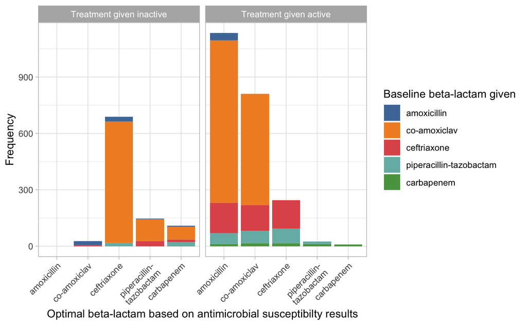

```r
p3 = pt_list %>%
  count(optimal_rx_plot, baseline_abx_gp, active_betalactam) %>%
  ggplot(aes(x = optimal_rx_plot, y = n, fill = baseline_abx_gp)) +
  geom_bar(stat = 'identity', position = 'stack') +
  scale_alpha_manual(name="Activity of beta-lactam given", values = c(0.5, 1)) +
  scale_fill_tableau(name="Baseline beta-lactam given") +
  xlab("Optimal beta-lactam based on antimicrobial susceptibilty results") +
  ylab("Frequency") +
  facet_wrap(~factor(active_betalactam, levels=c(0, 1), labels = c('Treatment given inactive', 'Treatment given active'))) +
  theme(axis.text.x = element_text(angle = 45, hjust = 1))
p3
```

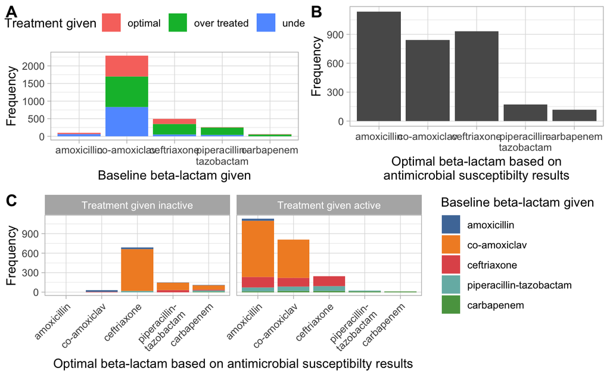

```r
r1 = cowplot::plot_grid(p1, p2, nrow = 1, labels = c('A', 'B'))
cowplot::plot_grid(r1, p3, nrow = 2, labels = c('', 'C'))
ggsave('figures/clinician_prescribing.pdf', width = 9.5, height = 8)
```

Can also calculate the implied sensitivity of clinician prescribing, for R to an abx, how many patients given active beta-lactam

```r
bind_rows(
  pt_list %>%
  filter(str_detect(ast_r, 'amoxicillin')) %>%
  summarise(n=n(), n_active_bl = sum(last_betalactam!='amoxicillin'), pct_active_bl = round(100*n_active_bl/n,0)) %>%
  mutate(abx='amoxicillin') %>%
  select(abx, n, n_active_bl, pct_active_bl),

  pt_list %>%
  filter(str_detect(ast_r, 'co-amoxiclav')) %>%
  summarise(n=n(), n_active_bl = sum(!last_betalactam %in% c('amoxicillin', 'co-amoxiclav')), pct_active_bl = round(100*n_active_bl/n,0)) %>%
  mutate(abx='co-amoxiclav') %>%
  select(abx, n, n_active_bl, pct_active_bl),

  pt_list %>%
  filter(str_detect(ast_r, 'ceftriaxone')) %>%
  summarise(n=n(), n_active_bl = sum(!last_betalactam %in% c('amoxicillin', 'co-amoxiclav', 'ceftriaxone')), pct_active_bl = round(100*n_active_bl/n,0)) %>%
  mutate(abx='ceftriaxone') %>%
  select(abx, n, n_active_bl, pct_active_bl),

  pt_list %>%
  filter(str_detect(ast_r, 'piperacillin-tazobactam')) %>%
  summarise(n=n(), n_active_bl = sum(!last_betalactam %in% c('amoxicillin', 'co-amoxiclav', 'ceftriaxone', 'piperacillin-tazobactam')), pct_active_bl = round(100*n_active_bl/n,0)) %>%
  mutate(abx='piperacillin-tazobactam') %>%
  select(abx, n, n_active_bl, pct_active_bl)
)
```

| abx | n | n_active_bl | pct_active_bl |
| --- | --- | --- | --- |
| amoxicillin | 2064 | 2005 | 97 |
| co-amoxiclav | 1225 | 360 | 29 |
| ceftriaxone | 320 | 61 | 19 |
| piperacillin-tazobactam | 190 | 11 | 6 |

```r
NA
```

```r
df_ast %>%
  filter(dataset != 'train') %>%
  mutate(filter_threshold = case_when(
    abx == "amoxicillin" ~ 0.385,
    abx == "co-amoxiclav" ~ 0.47692,
    abx == "ceftriaxone" ~ 0.12689,
    abx == "piperacillin-tazobactam" ~ 0.27
  )) %>%
  filter(!is.na(filter_threshold))  %>%
  group_by(abx) %>%
  summarise(n=n(), n_r = sum(true_y==1), n_s = n-n_r,
            pred_r_if_r = sum(true_y==1 & calib_pred_y>=filter_threshold), sens = round(100*pred_r_if_r/n_r,1),
            pred_s_if_s = sum(true_y==0 & calib_pred_y<filter_threshold), spec = round(100*pred_s_if_s/n_s,1)
            )
```

[output not shown]

## Join AST results to predictions

get ast results and predictions

```r
df_ast = df %>%
  select(abx, dataset, pt, index_dt, INFO_accessionnumber, calib_pred_y, calib_prob_y, true_y) %>%
  unique()
```

pivot to wide format

```r
# pivot wider
df_ast_wider = df_ast %>%
  pivot_wider(names_from = abx, values_from = c(calib_pred_y, calib_prob_y, true_y))
```

```r
# join back to pt_list
df_analysis = pt_list %>%
  inner_join(df_ast_wider, by = c('dataset', 'pt', 'index_dt', 'INFO_accessionnumber'))
#df_analysis
```

… Now have df_analysis with one row per blood culture for use in subsequent analyses.

## Scenario 1 - match to beta-lactam use

### Scenario 1 - training data

Target antibiotic use to beta-lactam use during training period

```r
df_analysis %>%
  filter(dataset == 'train') %>%
  count(baseline_abx_gp)
```

| baseline_abx_gp | n |
| --- | --- |
| amoxicillin | 61 |
| co-amoxiclav | 1623 |
| ceftriaxone | 365 |
| piperacillin-tazobactam | 178 |
| carbapenem | 52 |

Manually adjust thresholds using training data - to get same antibiotic use, and create df_suggest_train from df_analysis

```r
df_suggest_train = df_analysis %>%
  filter(dataset == 'train') %>%
  mutate(suggest = case_when(
    calib_prob_y_amoxicillin < 0.441 ~ 'amoxicillin',
    `calib_prob_y_co-amoxiclav` < 0.479 ~ 'co-amoxiclav',
    calib_prob_y_ceftriaxone < 0.1345 ~ 'ceftriaxone',
    `calib_prob_y_piperacillin-tazobactam` < 0.285 ~ 'piperacillin-tazobactam',
    TRUE ~ 'meropenem'
  )) %>%
  mutate(prediction_active = ifelse(str_detect(ast_s, suggest), 1, 0)) %>%
  mutate(suggest = ifelse(suggest == "meropenem", "carbapenem", suggest))
df_suggest_train %>% count(antibiotic=suggest)
```

| antibiotic | n |
| --- | --- |
| amoxicillin | 61 |
| carbapenem | 52 |
| ceftriaxone | 365 |
| co-amoxiclav | 1623 |
| piperacillin-tazobactam | 178 |

Compare whether actual beta-lactam or suggested beta-lactam is sensitive within training data

```r
df_suggest_train %>%
  summarise(n(), n_active = sum(active_abx), n_active_bl = sum(active_betalactam), pct_active_bl = round(100*sum(active_betalactam)/n(),1),
            n_prediction_active = sum(prediction_active), pct_prediction_active = round(100*sum(prediction_active)/n(),1))
```

| n() | n_active | n_active_bl | pct_active_bl | n_prediction_active | pct_prediction_active |
| --- | --- | --- | --- | --- | --- |
| 2279 | 1792 | 1585 | 69.5 | 1756 | 77.1 |

Report degree of over treatment

```r
classify_rx = function(df) {
  df %>%
  mutate(suggest_rx = case_when(
    prediction_active == 0 ~ 'under_treated',
    suggest == 'amoxicillin' & prediction_active == 1 ~ 'optimal',
    suggest == 'co-amoxiclav' & prediction_active == 1 & str_detect('amoxicillin', ast_s_search) ~ 'over_treated',
    suggest == 'co-amoxiclav' & prediction_active == 1 & !str_detect('amoxicillin', ast_s_search) ~ 'optimal',
    suggest == 'ceftriaxone' & prediction_active == 1 & str_detect('amoxicillin|co-amoxiclav', ast_s_search) ~ 'over_treated',
    suggest == 'ceftriaxone' & prediction_active == 1 & !str_detect('amoxicillin|co-amoxiclav', ast_s_search) ~ 'optimal',
    suggest == 'piperacillin-tazobactam' & prediction_active == 1 & str_detect('amoxicillin|co-amoxiclav|ceftriaxone', ast_s_search) ~ 'over_treated',
    suggest == 'piperacillin-tazobactam' & prediction_active == 1 & !str_detect('amoxicillin|co-amoxiclav|ceftriaxone', ast_s_search) ~ 'optimal',
    suggest == 'carbapenem' & prediction_active == 1 & str_detect('amoxicillin|co-amoxiclav|ceftriaxone|piperacillin-tazobactam', ast_s_search) ~ 'over_treated',
    suggest == 'carbapenem' & prediction_active == 1 & !str_detect('amoxicillin|co-amoxiclav|ceftriaxone|piperacillin-tazobactam', ast_s_search) ~ 'optimal'
  ))
}
```

Over treatment with predictor

```r
df_suggest_train %>% classify_rx %>% count(suggest_rx) %>% mutate(pct = round(100*n/sum(n)))
```

| suggest_rx | n | pct |
| --- | --- | --- |
| optimal | 816 | 36 |
| over_treated | 940 | 41 |
| under_treated | 523 | 23 |

… vs actual

```r
df_analysis %>%
  filter(dataset == 'train') %>%
  count(rx) %>% mutate(pct = round(100*n/sum(n)))
```

| rx | n | pct |
| --- | --- | --- |
| optimal | 568 | 25 |
| over_treated | 1017 | 45 |
| under_treated | 694 | 30 |

### Scenario 1 - test data

Apply the thresholds above to the test data

```r
df_suggest_train = df_analysis %>%
  filter(dataset != 'train') %>%
  mutate(suggest = case_when(
    calib_prob_y_amoxicillin < 0.441 ~ 'amoxicillin',
    `calib_prob_y_co-amoxiclav` < 0.479 ~ 'co-amoxiclav',
    calib_prob_y_ceftriaxone < 0.1345 ~ 'ceftriaxone',
    `calib_prob_y_piperacillin-tazobactam` < 0.285 ~ 'piperacillin-tazobactam',
    TRUE ~ 'meropenem'
  )) %>%
  mutate(prediction_active = ifelse(str_detect(ast_s, suggest), 1, 0)) %>%
  mutate(suggest = ifelse(suggest == "meropenem", "carbapenem", suggest))
```

Suggested antibiotic use

```r
df_suggest_train %>% count(antibiotic=suggest) %>% mutate(pct = round(100*n/sum(n)))
```

| antibiotic | n | pct |
| --- | --- | --- |
| amoxicillin | 10 | 1 |
| carbapenem | 19 | 2 |
| ceftriaxone | 164 | 18 |
| co-amoxiclav | 681 | 74 |
| piperacillin-tazobactam | 45 | 5 |

… vs. actual

```r
df_analysis %>%
  filter(dataset != 'train') %>%
  count(baseline_abx_gp) %>% mutate(pct = round(100*n/sum(n)))
```

| baseline_abx_gp | n | pct |
| --- | --- | --- |
| amoxicillin | 37 | 4 |
| co-amoxiclav | 663 | 72 |
| ceftriaxone | 130 | 14 |
| piperacillin-tazobactam | 79 | 9 |
| carbapenem | 10 | 1 |

Performance of suggestions vs actual

```r
df_suggest_train %>%
  summarise(n(), n_active = sum(active_abx), n_active_bl = sum(active_betalactam), pct_active_bl = round(100*sum(active_betalactam)/n(),0),
            n_prediction_active = sum(prediction_active), pct_prediction_active = round(100*sum(prediction_active)/n(),0))
```

| n() | n_active | n_active_bl | pct_active_bl | n_prediction_active | pct_prediction_active |
| --- | --- | --- | --- | --- | --- |
| 919 | 720 | 639 | 70 | 693 | 75 |

Degree of over treatment

```r
df_suggest_train %>% classify_rx %>% count(suggest_rx) %>% mutate(pct = round(100*n/sum(n)))
```

| suggest_rx | n | pct |
| --- | --- | --- |
| optimal | 305 | 33 |
| over_treated | 388 | 42 |
| under_treated | 226 | 25 |

… vs actual

```r
df_analysis %>%
  filter(dataset != 'train') %>%
  count(rx) %>% mutate(pct = round(100*n/sum(n)))
```

| rx | n | pct |
| --- | --- | --- |
| optimal | 238 | 26 |
| over_treated | 401 | 44 |
| under_treated | 280 | 30 |

Add sankey plot

```r
# install.packages("remotes")
# remotes::install_github("davidsjoberg/ggsankey")
library(ggsankey)
```

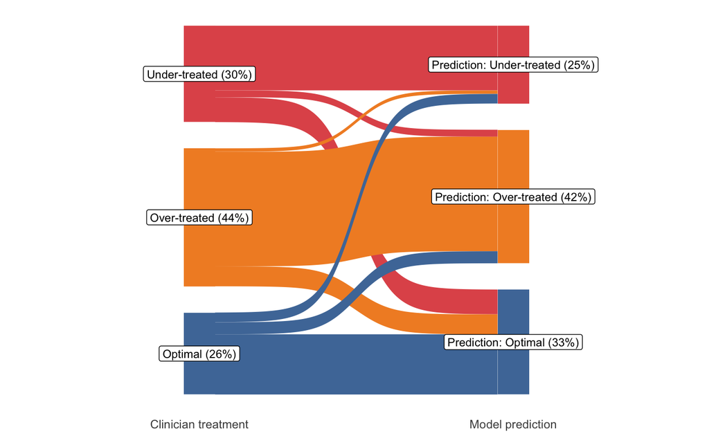

```r
dfp = df_suggest_train %>% classify_rx %>%
  mutate(suggest_rx = paste0('Prediction: ', str_replace(str_to_sentence(suggest_rx), "_", "-"))) %>%
  mutate(rx = str_replace(str_to_sentence(rx), "_", "-")) %>%
  select(`Clinician treatment`=rx, `Model prediction`=suggest_rx) %>%
  make_long(`Clinician treatment`, `Model prediction`)

dfpn = dfp %>%
  group_by(node) %>%
  tally() %>%
  mutate(pred = ifelse(str_detect(node, 'Prediction'), 1, 0)) %>%
  group_by(pred) %>%
  mutate(n_gp = sum(n), pct = round(100*n/n_gp,0))

dfp2 = merge(dfp, dfpn, by.x = 'node', by.y = 'node', all.x = TRUE)

p1 = dfp2 %>%
  mutate(fill_node = str_replace(node, "Prediction: ", "")) %>%
  ggplot(aes(x = x, next_x = next_x, node=node, next_node=next_node, fill=fill_node, label=paste0(node, " (", pct, "%)"))) +
  geom_sankey() +
  xlab("") +
  theme_minimal() +
  theme(axis.title = element_blank()
                  , axis.text.y = element_blank()
                  , axis.ticks = element_blank()
                  , panel.grid = element_blank()) +
  scale_fill_tableau(name="Clincian Treatment") +
  theme(legend.position = "none") +
  geom_sankey_label(size = 3, color = "black", fill= "white", hjust = 0.5)
p1
```

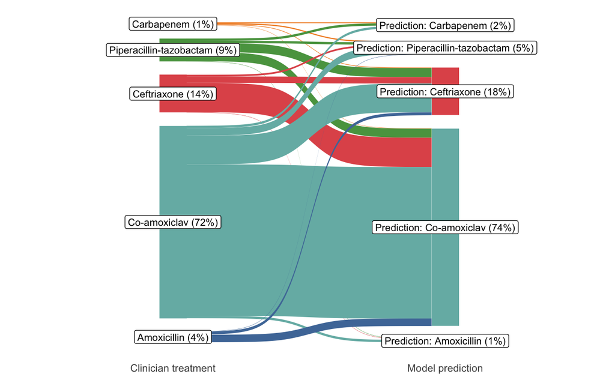

```r
dfp = df_suggest_train %>%
  mutate(last_betalactam = ifelse(last_betalactam=="meropenem" | last_betalactam=="ertapenem", "carbapenem", last_betalactam)) %>%
  mutate(last_betalactam = str_to_sentence(last_betalactam)) %>%
  mutate(suggest = str_to_sentence(suggest)) %>%
  mutate(last_betalactam = factor(last_betalactam, levels = c('Amoxicillin', 'Co-amoxiclav', 'Ceftriaxone', 'Piperacillin-tazobactam', 'Carbapenem'))) %>%
  mutate(suggest = factor(suggest, levels = c('Amoxicillin', 'Co-amoxiclav', 'Ceftriaxone', 'Piperacillin-tazobactam', 'Carbapenem'),
                          labels = c('Prediction: Amoxicillin', 'Prediction: Co-amoxiclav', 'Prediction: Ceftriaxone',
                                     'Prediction: Piperacillin-tazobactam', 'Prediction: Carbapenem'))) %>%
  select(`Clinician treatment`=last_betalactam, `Model prediction`=suggest) %>%
  make_long(`Clinician treatment`, `Model prediction`) %>%
  mutate(node = factor(node, levels = c('Amoxicillin', 'Co-amoxiclav', 'Ceftriaxone', 'Piperacillin-tazobactam', 'Carbapenem',
                                        'Prediction: Amoxicillin', 'Prediction: Co-amoxiclav', 'Prediction: Ceftriaxone',
                                     'Prediction: Piperacillin-tazobactam', 'Prediction: Carbapenem'))) %>%
  mutate(next_node = factor(next_node, levels = c('Prediction: Amoxicillin', 'Prediction: Co-amoxiclav', 'Prediction: Ceftriaxone',
                                     'Prediction: Piperacillin-tazobactam', 'Prediction: Carbapenem')))
dfpn = dfp %>%
  group_by(node) %>%
  tally() %>%
  mutate(pred = ifelse(str_detect(node, 'Prediction'), 1, 0)) %>%
  group_by(pred) %>%
  mutate(n_gp = sum(n), pct = round(100*n/n_gp,0))

dfp2 = merge(dfp, dfpn, by.x = 'node', by.y = 'node', all.x = TRUE)

p2 = dfp2 %>%
  mutate(fill_node = str_replace(node, "Prediction: ", "")) %>%
  ggplot(aes(x = x, next_x = next_x, node=node, next_node=next_node, fill=fill_node, label=paste0(node," (", pct, "%)"))) +
  geom_sankey() +
  xlab("") +
  theme_minimal() +
  theme(axis.title = element_blank()
                  , axis.text.y = element_blank()
                  , axis.ticks = element_blank()
                  , panel.grid = element_blank()) +
  scale_fill_tableau(name="Clincian Treatment") +
  theme(legend.position = "none") +
  geom_sankey_label(size = 3, color = "black", fill= "white", hjust = 0.5)
p2
```

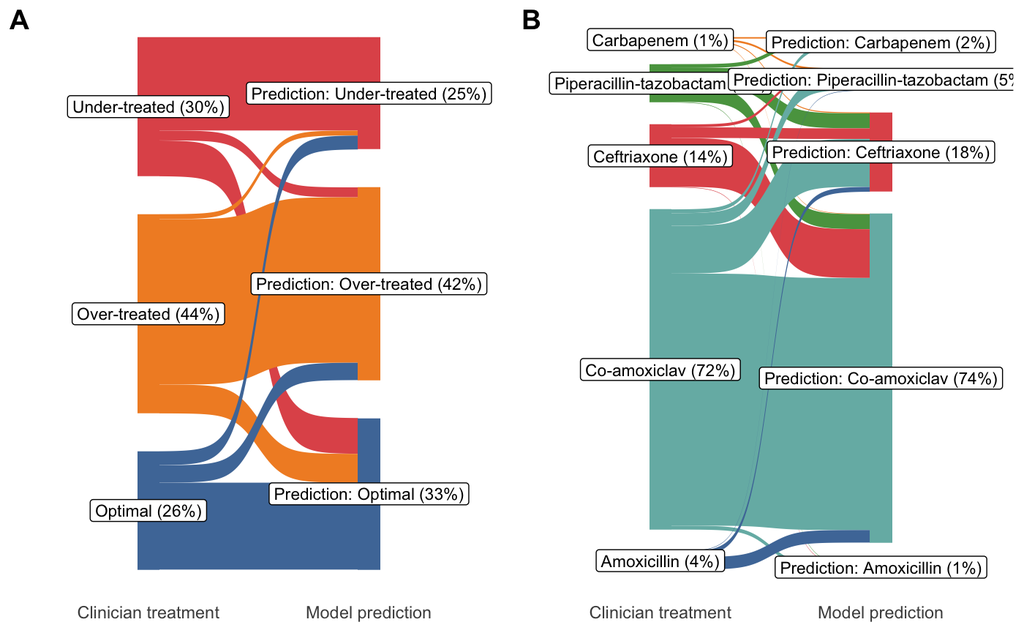

```r
plot_grid(p1, p2, nrow = 1, labels = c('A', 'B'))
ggsave('figures/clinical_vs_model.pdf', width = 10, height = 5)
```

## Scenario 2 - train algorithm against optimal tretment thresholds

```r
pt_list %>%
  filter(dataset=="train") %>%
  count(optimal_rx)
```

| optimal_rx | n |
| --- | --- |
| amoxicillin | 804 |
| co-amoxiclav | 584 |
| ceftriaxone | 682 |
| piperacillin-tazobactam | 125 |
| carbapenem | 84 |

```r
df_suggest = df_analysis %>%
  filter(dataset == 'train') %>%
  mutate(suggest = case_when(
    calib_prob_y_amoxicillin < 0.5452 ~ 'amoxicillin',
    `calib_prob_y_co-amoxiclav` < 0.3845 ~ 'co-amoxiclav',
    calib_prob_y_ceftriaxone < 0.161 ~ 'ceftriaxone',
    `calib_prob_y_piperacillin-tazobactam` < 0.16 ~ 'piperacillin-tazobactam',
    TRUE ~ 'meropenem'
  )) %>%
  mutate(prediction_active = ifelse(str_detect(ast_s, suggest), 1, 0)) %>%
  mutate(suggest = ifelse(suggest == "meropenem", "carbapenem", suggest))
df_suggest %>% count(antibiotic=suggest)
```

| antibiotic | n |
| --- | --- |
| amoxicillin | 804 |
| carbapenem | 84 |
| ceftriaxone | 682 |
| co-amoxiclav | 584 |
| piperacillin-tazobactam | 125 |

## check peformance on test data

Suggestions

```r
df_suggest_train = df_analysis %>%
  filter(dataset != 'train') %>%
  mutate(suggest = case_when(
    calib_prob_y_amoxicillin < 0.5452 ~ 'amoxicillin',
    `calib_prob_y_co-amoxiclav` < 0.3845 ~ 'co-amoxiclav',
    calib_prob_y_ceftriaxone < 0.161 ~ 'ceftriaxone',
    `calib_prob_y_piperacillin-tazobactam` < 0.16 ~ 'piperacillin-tazobactam',
    TRUE ~ 'meropenem'
  )) %>%
  mutate(prediction_active = ifelse(str_detect(ast_s, suggest), 1, 0)) %>%
  mutate(suggest = ifelse(suggest == "meropenem", "carbapenem", suggest))
df_suggest_train %>% count(antibiotic=suggest) %>% mutate(pct = round(100*n/sum(n)))
```

| antibiotic | n | pct |
| --- | --- | --- |
| amoxicillin | 320 | 35 |
| carbapenem | 37 | 4 |
| ceftriaxone | 301 | 33 |
| co-amoxiclav | 238 | 26 |
| piperacillin-tazobactam | 23 | 3 |

Performance of suggestions vs actual

```r
df_suggest_train %>%
  summarise(n(), n_active = sum(active_abx), n_active_bl = sum(active_betalactam), pct_active_bl = round(100*sum(active_betalactam)/n(),0),
            n_prediction_active = sum(prediction_active), pct_prediction_active = round(100*sum(prediction_active)/n(),0))
```

| n() | n_active | n_active_bl | pct_active_bl | n_prediction_active | pct_prediction_active |
| --- | --- | --- | --- | --- | --- |
| 919 | 720 | 639 | 70 | 655 | 71 |

```r
df_suggest_train %>% classify_rx %>% count(suggest_rx) %>% mutate(pct = round(100*n/sum(n)))
```

| suggest_rx | n | pct |
| --- | --- | --- |
| optimal | 384 | 42 |
| over_treated | 271 | 29 |
| under_treated | 264 | 29 |

Allow for 20% error margin

```r
opt_list = pt_list %>%
  filter(dataset=="train") %>%
  count(optimal_rx) %>%
  mutate(n_optimal = ifelse(optimal_rx=="amoxicillin" | optimal_rx=="co-amoxiclav", round(0.8*n), n)) %>%
  mutate(upscale=1.312) %>%
  mutate(final_n = ifelse(optimal_rx=="amoxicillin" | optimal_rx=="co-amoxiclav", n_optimal, round(n*upscale)))

opt_list
```

| optimal_rx | n | n_optimal | upscale | final_n |
| --- | --- | --- | --- | --- |
| amoxicillin | 804 | 643 | 1.312 | 643 |
| co-amoxiclav | 584 | 467 | 1.312 | 467 |
| ceftriaxone | 682 | 682 | 1.312 | 895 |
| piperacillin-tazobactam | 125 | 125 | 1.312 | 164 |
| carbapenem | 84 | 84 | 1.312 | 110 |

```r
opt_list %>% summarise(sum(n), sum(final_n))
```

| sum(n) | sum(final_n) |
| --- | --- |
| 2279 | 2279 |

```r
opt_list %>% select(optimal_rx, final_n)
```

| optimal_rx | final_n |
| --- | --- |
| amoxicillin | 643 |
| co-amoxiclav | 467 |
| ceftriaxone | 895 |
| piperacillin-tazobactam | 164 |
| carbapenem | 110 |

```r
df_suggest = df_analysis %>%
  filter(dataset == 'train') %>%
  mutate(suggest = case_when(
    calib_prob_y_amoxicillin < 0.52371 ~ 'amoxicillin',
    `calib_prob_y_co-amoxiclav` < 0.32762 ~ 'co-amoxiclav',
    calib_prob_y_ceftriaxone < 0.1358 ~ 'ceftriaxone',
    `calib_prob_y_piperacillin-tazobactam` < 0.145 ~ 'piperacillin-tazobactam',
    TRUE ~ 'meropenem'
  )) %>%
  mutate(prediction_active = ifelse(str_detect(ast_s, suggest), 1, 0)) %>%
  mutate(suggest = ifelse(suggest == "meropenem", "carbapenem", suggest))
df_suggest %>% count(antibiotic=suggest) %>% mutate(pct = round(100*n/sum(n)))
```

| antibiotic | n | pct |
| --- | --- | --- |
| amoxicillin | 643 | 28 |
| carbapenem | 110 | 5 |
| ceftriaxone | 895 | 39 |
| co-amoxiclav | 467 | 20 |
| piperacillin-tazobactam | 164 | 7 |

## check peformance on test data

Suggestions

```r
df_suggest_train = df_analysis %>%
  filter(dataset != 'train') %>%
  mutate(suggest = case_when(
    calib_prob_y_amoxicillin < 0.52371 ~ 'amoxicillin',
    `calib_prob_y_co-amoxiclav` < 0.32762 ~ 'co-amoxiclav',
    calib_prob_y_ceftriaxone < 0.1358 ~ 'ceftriaxone',
    `calib_prob_y_piperacillin-tazobactam` < 0.145 ~ 'piperacillin-tazobactam',
    TRUE ~ 'meropenem'
  )) %>%
  mutate(prediction_active = ifelse(str_detect(ast_s, suggest), 1, 0)) %>%
  mutate(suggest = ifelse(suggest == "meropenem", "carbapenem", suggest))
df_suggest_train %>% count(antibiotic=suggest) %>% mutate(pct = round(100*n/sum(n)))
```

| antibiotic | n | pct |
| --- | --- | --- |
| amoxicillin | 258 | 28 |
| carbapenem | 46 | 5 |
| ceftriaxone | 395 | 43 |
| co-amoxiclav | 194 | 21 |
| piperacillin-tazobactam | 26 | 3 |

Performance of suggestions vs actual

```r
df_suggest_train %>%
  summarise(n(), n_active = sum(active_abx), n_active_bl = sum(active_betalactam), pct_active_bl = round(100*sum(active_betalactam)/n(),0),
            n_prediction_active = sum(prediction_active), pct_prediction_active = round(100*sum(prediction_active)/n(),0))
```

| n() | n_active | n_active_bl | pct_active_bl | n_prediction_active | pct_prediction_active |
| --- | --- | --- | --- | --- | --- |
| 919 | 720 | 639 | 70 | 705 | 77 |

```r
df_suggest_train %>% classify_rx %>% count(suggest_rx) %>% mutate(pct = round(100*n/sum(n)))
```

| suggest_rx | n | pct |
| --- | --- | --- |
| optimal | 374 | 41 |
| over_treated | 331 | 36 |
| under_treated | 214 | 23 |

# scenario 3 - match over-treatment rates

```r
pt_list %>%
  filter(dataset == 'train') %>%
  count(rx) %>%
  mutate(pct = round(100*n/sum(n)))
```

| rx | n | pct |
| --- | --- | --- |
| optimal | 568 | 25 |
| over_treated | 1017 | 45 |
| under_treated | 694 | 30 |

Target - no more than 1017 over-treated, try to minimise under-treatment

```r
df_suggest = df_analysis %>%
  filter(dataset == 'train') %>%
  mutate(suggest = case_when(
    calib_prob_y_amoxicillin < 0.2 ~ 'amoxicillin',
    `calib_prob_y_co-amoxiclav` < 0.375 ~ 'co-amoxiclav',
    calib_prob_y_ceftriaxone < 0.58 ~ 'ceftriaxone',
    `calib_prob_y_piperacillin-tazobactam` < 0.3 ~ 'piperacillin-tazobactam',
    TRUE ~ 'meropenem'
  )) %>%
  mutate(prediction_active = ifelse(str_detect(ast_s, suggest), 1, 0)) %>%
  mutate(suggest = ifelse(suggest == "meropenem", "carbapenem", suggest)) %>%
  mutate(suggest_rx = case_when(
    prediction_active == 0 ~ 'under_treated',
    suggest == 'amoxicillin' & prediction_active == 1 ~ 'optimal',
    suggest == 'co-amoxiclav' & prediction_active == 1 & str_detect('amoxicillin', ast_s_search) ~ 'over_treated',
    suggest == 'co-amoxiclav' & prediction_active == 1 & !str_detect('amoxicillin', ast_s_search) ~ 'optimal',
    suggest == 'ceftriaxone' & prediction_active == 1 & str_detect('amoxicillin|co-amoxiclav', ast_s_search) ~ 'over_treated',
    suggest == 'ceftriaxone' & prediction_active == 1 & !str_detect('amoxicillin|co-amoxiclav', ast_s_search) ~ 'optimal',
    suggest == 'piperacillin-tazobactam' & prediction_active == 1 & str_detect('amoxicillin|co-amoxiclav|ceftriaxone', ast_s_search) ~ 'over_treated',
    suggest == 'piperacillin-tazobactam' & prediction_active == 1 & !str_detect('amoxicillin|co-amoxiclav|ceftriaxone', ast_s_search) ~ 'optimal',
    suggest == 'carbapenem' & prediction_active == 1 & str_detect('amoxicillin|co-amoxiclav|ceftriaxone|piperacillin-tazobactam', ast_s_search) ~ 'over_treated',
    suggest == 'carbapenem' & prediction_active == 1 & !str_detect('amoxicillin|co-amoxiclav|ceftriaxone|piperacillin-tazobactam', ast_s_search) ~ 'optimal'
  ))
df_suggest %>%
count(suggest_rx) %>%
    mutate(pct = round(100*n/sum(n)))
```

| suggest_rx | n | pct |
| --- | --- | --- |
| optimal | 807 | 35 |
| over_treated | 1017 | 45 |
| under_treated | 455 | 20 |

## check peformance on test data

Suggestions

```r
df_suggest_train = df_analysis %>%
  filter(dataset != 'train') %>%
  mutate(suggest = case_when(
    calib_prob_y_amoxicillin < 0.2 ~ 'amoxicillin',
    `calib_prob_y_co-amoxiclav` < 0.375 ~ 'co-amoxiclav',
    calib_prob_y_ceftriaxone < 0.58 ~ 'ceftriaxone',
    `calib_prob_y_piperacillin-tazobactam` < 0.3 ~ 'piperacillin-tazobactam',
    TRUE ~ 'meropenem'
  )) %>%
  mutate(prediction_active = ifelse(str_detect(ast_s, suggest), 1, 0)) %>%
  mutate(suggest = ifelse(suggest == "meropenem", "carbapenem", suggest))
df_suggest_train %>% count(antibiotic=suggest) %>% mutate(pct = round(100*n/sum(n)))
```

| antibiotic | n | pct |
| --- | --- | --- |
| carbapenem | 4 | 0 |
| ceftriaxone | 356 | 39 |
| co-amoxiclav | 543 | 59 |
| piperacillin-tazobactam | 16 | 2 |

Performance of suggestions vs actual

```r
df_suggest_train %>%
  summarise(n(), n_active = sum(active_abx), n_active_bl = sum(active_betalactam), pct_active_bl = round(100*sum(active_betalactam)/n(),0),
            n_prediction_active = sum(prediction_active), pct_prediction_active = round(100*sum(prediction_active)/n(),0))
```

| n() | n_active | n_active_bl | pct_active_bl | n_prediction_active | pct_prediction_active |
| --- | --- | --- | --- | --- | --- |
| 919 | 720 | 639 | 70 | 724 | 79 |

```r
df_suggest_train %>% classify_rx %>% count(suggest_rx) %>% mutate(pct = round(100*n/sum(n)))
```

| suggest_rx | n | pct |
| --- | --- | --- |
| optimal | 309 | 34 |
| over_treated | 415 | 45 |
| under_treated | 195 | 21 |

Naive move everyone to at least ceftriaxone

```r
df_suggest = df_analysis %>%
  filter(dataset != 'train') %>%
  mutate(suggest = case_when(
    baseline_abx_gp %in% c('amoxicillin', 'co-amoxiclav', 'ceftriaxone') ~ 'ceftriaxone',
    baseline_abx_gp == "piperacillin-tazobactam" ~ 'piperacillin-tazobactam',
    TRUE ~ 'meropenem')) %>%
  mutate(prediction_active = ifelse(str_detect(ast_s, suggest), 1, 0)) %>%
  mutate(suggest = ifelse(suggest == "meropenem", "carbapenem", suggest)) %>%
  mutate(suggest_rx = case_when(
    prediction_active == 0 ~ 'under_treated',
    suggest == 'amoxicillin' & prediction_active == 1 ~ 'optimal',
    suggest == 'co-amoxiclav' & prediction_active == 1 & str_detect('amoxicillin', ast_s_search) ~ 'over_treated',
    suggest == 'co-amoxiclav' & prediction_active == 1 & !str_detect('amoxicillin', ast_s_search) ~ 'optimal',
    suggest == 'ceftriaxone' & prediction_active == 1 & str_detect('amoxicillin|co-amoxiclav', ast_s_search) ~ 'over_treated',
    suggest == 'ceftriaxone' & prediction_active == 1 & !str_detect('amoxicillin|co-amoxiclav', ast_s_search) ~ 'optimal',
    suggest == 'piperacillin-tazobactam' & prediction_active == 1 & str_detect('amoxicillin|co-amoxiclav|ceftriaxone', ast_s_search) ~ 'over_treated',
    suggest == 'piperacillin-tazobactam' & prediction_active == 1 & !str_detect('amoxicillin|co-amoxiclav|ceftriaxone', ast_s_search) ~ 'optimal',
    suggest == 'carbapenem' & prediction_active == 1 & str_detect('amoxicillin|co-amoxiclav|ceftriaxone|piperacillin-tazobactam', ast_s_search) ~ 'over_treated',
    suggest == 'carbapenem' & prediction_active == 1 & !str_detect('amoxicillin|co-amoxiclav|ceftriaxone|piperacillin-tazobactam', ast_s_search) ~ 'optimal'
  ))

df_suggest %>% count(suggest_rx) %>% mutate(pct = round(100*n/sum(n)))
```

| suggest_rx | n | pct |
| --- | --- | --- |
| optimal | 221 | 24 |
| over_treated | 596 | 65 |
| under_treated | 102 | 11 |

```r
df_suggest %>% summarise(sum(prediction_active), n=n(), pct=round(100*sum(prediction_active)/n(),0))
```

| sum(prediction_active) | n | pct |
| --- | --- | --- |
| 817 | 919 | 89 |

```r
df_suggest %>% count(suggest) %>% mutate(pct = round(100*n/sum(n)))
```

| suggest | n | pct |
| --- | --- | --- |
| carbapenem | 10 | 1 |
| ceftriaxone | 830 | 90 |
| piperacillin-tazobactam | 79 | 9 |

# scenario 4 - match under-treatment rates,

target under-treatment of 102

```r
df_suggest = df_analysis %>%
  filter(dataset == 'train') %>%
  mutate(suggest = case_when(
    calib_prob_y_amoxicillin < 0.4 ~ 'amoxicillin',
    `calib_prob_y_co-amoxiclav` < 0.255 ~ 'co-amoxiclav',
    calib_prob_y_ceftriaxone < 0.6 ~ 'ceftriaxone',
    `calib_prob_y_piperacillin-tazobactam` < 0.3 ~ 'piperacillin-tazobactam',
    TRUE ~ 'meropenem'
  )) %>%
  mutate(prediction_active = ifelse(str_detect(ast_s, suggest), 1, 0)) %>%
  mutate(suggest = ifelse(suggest == "meropenem", "carbapenem", suggest)) %>%
  mutate(suggest_rx = case_when(
    prediction_active == 0 ~ 'under_treated',
    suggest == 'amoxicillin' & prediction_active == 1 ~ 'optimal',
    suggest == 'co-amoxiclav' & prediction_active == 1 & str_detect('amoxicillin', ast_s_search) ~ 'over_treated',
    suggest == 'co-amoxiclav' & prediction_active == 1 & !str_detect('amoxicillin', ast_s_search) ~ 'optimal',
    suggest == 'ceftriaxone' & prediction_active == 1 & str_detect('amoxicillin|co-amoxiclav', ast_s_search) ~ 'over_treated',
    suggest == 'ceftriaxone' & prediction_active == 1 & !str_detect('amoxicillin|co-amoxiclav', ast_s_search) ~ 'optimal',
    suggest == 'piperacillin-tazobactam' & prediction_active == 1 & str_detect('amoxicillin|co-amoxiclav|ceftriaxone', ast_s_search) ~ 'over_treated',
    suggest == 'piperacillin-tazobactam' & prediction_active == 1 & !str_detect('amoxicillin|co-amoxiclav|ceftriaxone', ast_s_search) ~ 'optimal',
    suggest == 'carbapenem' & prediction_active == 1 & str_detect('amoxicillin|co-amoxiclav|ceftriaxone|piperacillin-tazobactam', ast_s_search) ~ 'over_treated',
    suggest == 'carbapenem' & prediction_active == 1 & !str_detect('amoxicillin|co-amoxiclav|ceftriaxone|piperacillin-tazobactam', ast_s_search) ~ 'optimal'
  ))
df_suggest %>%
count(suggest_rx) %>%
    mutate(pct = round(100*n/sum(n)))
```

| suggest_rx | n | pct |
| --- | --- | --- |
| optimal | 810 | 36 |
| over_treated | 1270 | 56 |
| under_treated | 199 | 9 |

## check peformance on test data

Suggestions

```r
df_suggest_train = df_analysis %>%
  filter(dataset != 'train') %>%
  mutate(suggest = case_when(
    calib_prob_y_amoxicillin < 0.4 ~ 'amoxicillin',
    `calib_prob_y_co-amoxiclav` < 0.255 ~ 'co-amoxiclav',
    calib_prob_y_ceftriaxone < 0.6 ~ 'ceftriaxone',
    `calib_prob_y_piperacillin-tazobactam` < 0.3 ~ 'piperacillin-tazobactam',
    TRUE ~ 'meropenem'
  )) %>%
  mutate(prediction_active = ifelse(str_detect(ast_s, suggest), 1, 0)) %>%
  mutate(suggest = ifelse(suggest == "meropenem", "carbapenem", suggest))
df_suggest_train %>% count(antibiotic=suggest) %>% mutate(pct = round(100*n/sum(n)))
```

| antibiotic | n | pct |
| --- | --- | --- |
| amoxicillin | 5 | 1 |
| carbapenem | 4 | 0 |
| ceftriaxone | 836 | 91 |
| co-amoxiclav | 59 | 6 |
| piperacillin-tazobactam | 15 | 2 |

Performance of suggestions vs actual

```r
df_suggest_train %>%
  summarise(n(), n_active = sum(active_abx), n_active_bl = sum(active_betalactam), pct_active_bl = round(100*sum(active_betalactam)/n(),0),
            n_prediction_active = sum(prediction_active), pct_prediction_active = round(100*sum(prediction_active)/n(),0))
```

| n() | n_active | n_active_bl | pct_active_bl | n_prediction_active | pct_prediction_active |
| --- | --- | --- | --- | --- | --- |
| 919 | 720 | 639 | 70 | 822 | 89 |

```r
df_suggest_train %>% classify_rx %>% count(suggest_rx) %>% mutate(pct = round(100*n/sum(n)))
```

| suggest_rx | n | pct |
| --- | --- | --- |
| optimal | 282 | 31 |
| over_treated | 540 | 59 |
| under_treated | 97 | 11 |